# Make Countries Move

Terkel Sylvester Jacobsen

20/03/2026

# Explore global development with R

In this exercise, you will load a filtered `gapminder` dataset - with a subset of data on global development from 1952 - 2007 in increments of 5 years - to capture the period between the Second World War and the Global Financial Crisis.

**Your task: Explore the data and visualise it in both static and animated ways, providing answers and solutions to 7 questions/tasks within this script.**

- **Submit to Github this script with solutions and its knitted version.**
- **Submit to Brightspace a document with the (1) URL of this script and its knitted version in Github (2) answer of 250 words and a (3) visualisation of the Final Question**

## Get the necessary packages

First, start with installing and activating the relevant packages `tidyverse`, `gganimate`, and `gapminder` if you do not have them already. *Pay attention to what warning messages you get when installing `gganimate`, as your computer might need other packages than `gifski` and `av`*

## Look at the data and tackle the tasks

First, see which specific years are actually represented in the dataset and what variables are being recorded for each country. Note that when you run the cell below, Rmarkdown will give you two results - one for each line - that you can flip between.

```r
str(gapminder) # factor = Constrained character - so R knows it is the same country when mentioned multiple times
```

```
## tibble [1,704 × 6] (S3: tbl_df/tbl/data.frame)
##  $ country  : Factor w/ 142 levels "Afghanistan",..: 1 1 1 1 1 1 1 1 1 1 ...
##  $ continent: Factor w/ 5 levels "Africa","Americas",..: 3 3 3 3 3 3 3 3 3 3 ...
##  $ year     : int [1:1704] 1952 1957 1962 1967 1972 1977 1982 1987 1992 1997 ...
##  $ lifeExp  : num [1:1704] 28.8 30.3 32 34 36.1 ...
##  $ pop      : int [1:1704] 8425333 9240934 10267083 11537966 13079460 14880372 12881816 13867957 16317921 22227415 ...
##  $ gdpPercap: num [1:1704] 779 821 853 836 740 ...
```

```r
unique(gapminder$year)
```

```
##  [1] 1952 1957 1962 1967 1972 1977 1982 1987 1992 1997 2002 2007
```

```r
unique(gapminder$country)
```

```
##   [1] Afghanistan              Albania                  Algeria
##   [4] Angola                   Argentina                Australia
##   [7] Austria                  Bahrain                  Bangladesh
##  [10] Belgium                  Benin                    Bolivia
##  [13] Bosnia and Herzegovina   Botswana                 Brazil
##  [16] Bulgaria                 Burkina Faso             Burundi
##  [19] Cambodia                 Cameroon                 Canada
##  [22] Central African Republic Chad                     Chile
##  [25] China                    Colombia                 Comoros
##  [28] Congo, Dem. Rep.         Congo, Rep.              Costa Rica
##  [31] Cote d'Ivoire            Croatia                  Cuba
##  [34] Czech Republic           Denmark                  Djibouti
##  [37] Dominican Republic       Ecuador                  Egypt
##  [40] El Salvador              Equatorial Guinea        Eritrea
##  [43] Ethiopia                 Finland                  France
```

[output cut: 34 more lines]

```r
head(gapminder)
```

```
## # A tibble: 6 × 6
##   country     continent  year lifeExp      pop gdpPercap
##   <fct>       <fct>     <int>   <dbl>    <int>     <dbl>
## 1 Afghanistan Asia       1952    28.8  8425333      779.
## 2 Afghanistan Asia       1957    30.3  9240934      821.
## 3 Afghanistan Asia       1962    32.0 10267083      853.
## 4 Afghanistan Asia       1967    34.0 11537966      836.
## 5 Afghanistan Asia       1972    36.1 13079460      740.
## 6 Afghanistan Asia       1977    38.4 14880372      786.
```

The dataset contains information on each country in the sampled year, its continent, life expectancy, population, and GDP per capita.

Let’s plot all the countries in 1952.

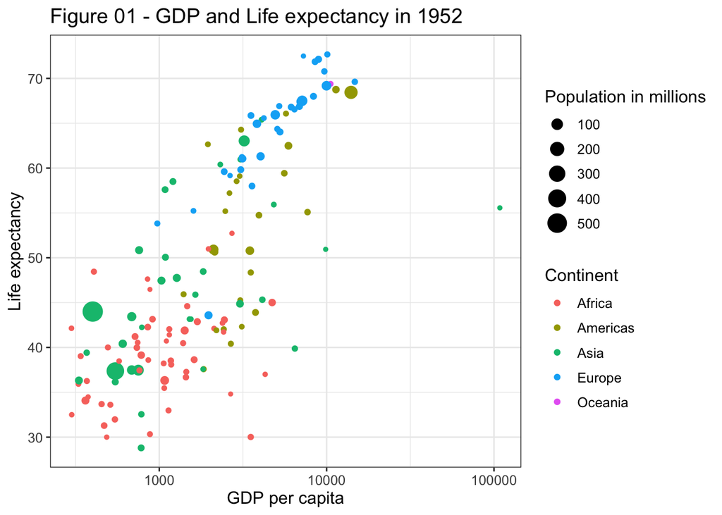

```r
theme_set(theme_bw())  # set theme to white background for better visibility
options(scipen=999)

gapminder %>%
  filter(year == 1952) %>%
  ggplot(aes(gdpPercap, lifeExp, size = pop/1000000)) +
  geom_point(aes(color = continent)) +
  scale_x_log10() +
  ggtitle("Figure 01 - GDP and Life expectancy in 1952") +
  theme(text = element_text(size = 12)) +
  labs(size = "Population in millions",
       x = "GDP per capita",
       y = "Life expectancy",
       color = "Continent")
```

```r
# to find the outlier - with the largest gdpPercap - I arrange by descending gdpPercap
gapminder %>%
  filter(year==1952) %>%
  arrange(desc(gdpPercap))
```

```
## # A tibble: 142 × 6
##    country        continent  year lifeExp       pop gdpPercap
##    <fct>          <fct>     <int>   <dbl>     <int>     <dbl>
##  1 Kuwait         Asia       1952    55.6    160000   108382.
##  2 Switzerland    Europe     1952    69.6   4815000    14734.
##  3 United States  Americas   1952    68.4 157553000    13990.
##  4 Canada         Americas   1952    68.8  14785584    11367.
##  5 New Zealand    Oceania    1952    69.4   1994794    10557.
##  6 Norway         Europe     1952    72.7   3327728    10095.
##  7 Australia      Oceania    1952    69.1   8691212    10040.
##  8 United Kingdom Europe     1952    69.2  50430000     9980.
##  9 Bahrain        Asia       1952    50.9    120447     9867.
## 10 Denmark        Europe     1952    70.8   4334000     9692.
## # ℹ 132 more rows
```

…

Next, you can generate a similar plot for 2007 and compare the differences

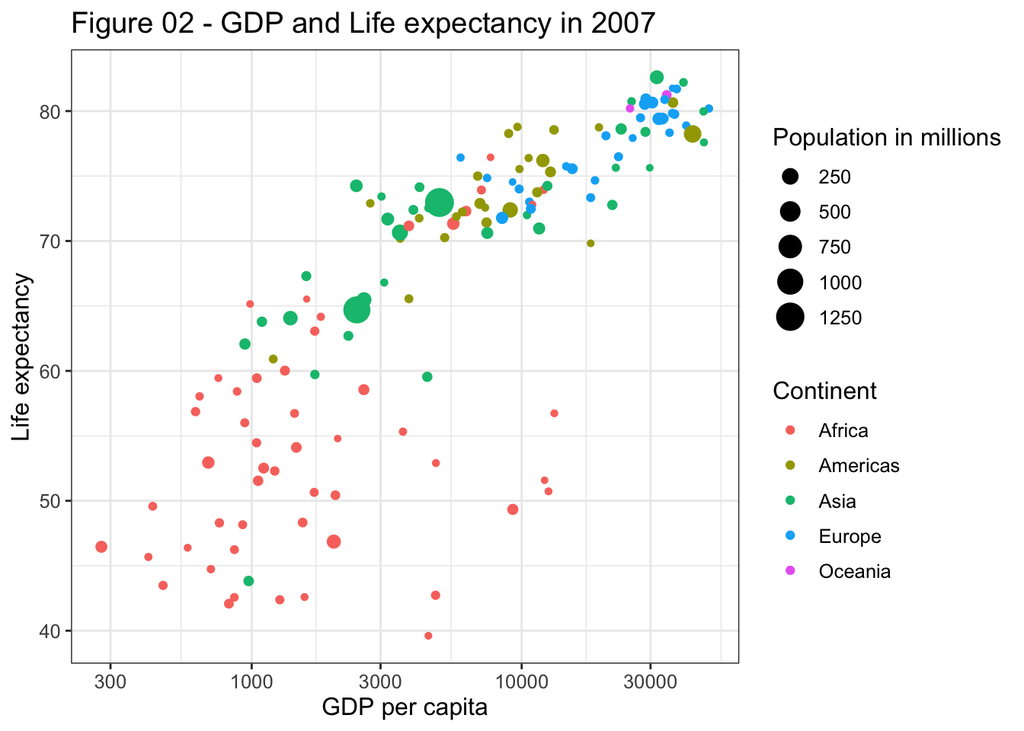

```r
gapminder %>%
  filter(year == 2007) %>%
  ggplot(aes(gdpPercap, lifeExp, size = pop/1000000)) +
  geom_point(aes(color = continent)) +
  scale_x_log10() +
  ggtitle("Figure 02 - GDP and Life expectancy in 2007") +
  theme(text = element_text(size = 12)) +
  labs(size = "Population in millions",
       x = "GDP per capita",
       y = "Life expectancy",
       color = "Continent")
```

```r
# to find the 5 richest countries in 2007
gapminder %>%
  filter(year==2007) %>%
  arrange(desc(gdpPercap))
```

```
## # A tibble: 142 × 6
##    country          continent  year lifeExp       pop gdpPercap
##    <fct>            <fct>     <int>   <dbl>     <int>     <dbl>
##  1 Norway           Europe     2007    80.2   4627926    49357.
##  2 Kuwait           Asia       2007    77.6   2505559    47307.
##  3 Singapore        Asia       2007    80.0   4553009    47143.
##  4 United States    Americas   2007    78.2 301139947    42952.
##  5 Ireland          Europe     2007    78.9   4109086    40676.
##  6 Hong Kong, China Asia       2007    82.2   6980412    39725.
##  7 Switzerland      Europe     2007    81.7   7554661    37506.
##  8 Netherlands      Europe     2007    79.8  16570613    36798.
##  9 Canada           Americas   2007    80.7  33390141    36319.
## 10 Iceland          Europe     2007    81.8    301931    36181.
## # ℹ 132 more rows
```

…

### Questions for the static figures:

1. *Answer: why does it make sense to have a log10 scale (`scale_x_log10()`) on the x axis?* (hint: try to comment it out and observe the result)

Otherwise, almost every country is right on top of each other - perhaps due to the outlier (see below) having an incredibly high GDP per capita

2. *Answer: In Figure 1: Who is the outlier (the richest country in 1952) far right on the x axis?*

By looking at the gapminder dataset filtered by 1952, sorted by descending gdpPercap, we see that the country with the largest GDP per capita by far is Kuwait - with a staggering 108382 dollars, the runner-up being Switzerland with 14734 dollars

3. *Fix Figures 1 and 2: Differentiate the continents by color, and fix the axis labels and units to be more legible (**Hint**: the 2.50e+08 is so called “scientific notation”. You want to eliminate it.)*
4. *Answer: What are the five richest countries in the world in 2007?*

Norway - $49357 per capita

Kuwait - $47306 per capita

Singapore - $47143 per capita

United States - $42951 per capita

Ireland - $40675 per capita

## Make it move!

The comparison would be easier if we had the two graphs together, animated. We have a lovely tool in R to do this: the `gganimate` package. Beware that there may be other packages your operating system needs in order to glue interim images into an animation or video. Read the messages when installing the package.

Also, there are *two* ways of animating the gapminder ggplot.

### Option 1: Animate using transition_states()

The first step is to create the object-to-be-animated

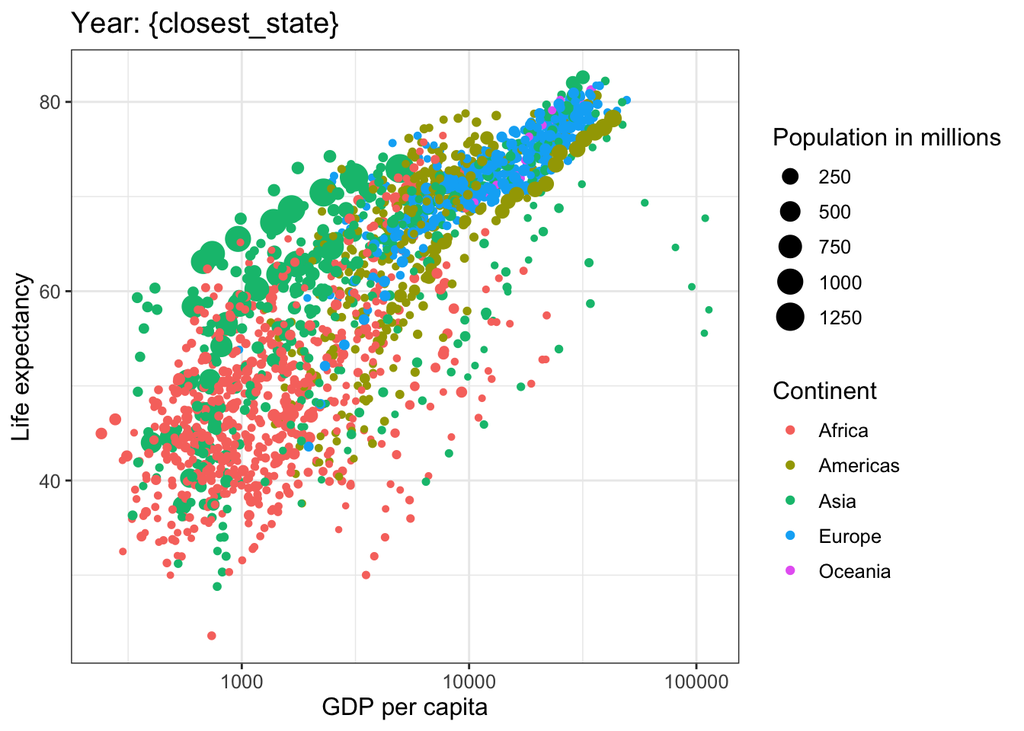

```r
anim <- ggplot(gapminder, aes(gdpPercap, lifeExp, size = pop/1000000)) +
  geom_point(aes(color=continent)) +
  scale_x_log10() +  # convert x to log scale
  theme(text = element_text(size = 12)) +
  labs(size = "Population in millions",
       x = "GDP per capita",
       y = "Life expectancy",
       color = "Continent",
       title = 'Year: {closest_state}')
anim
```

…

This plot collates all the points across time. The next step is to split it into years and animate it. This may take some time, depending on the processing power of your computer (and other things you are asking it to do). Beware that the animation might appear in the bottom right ‘Viewer’ pane, not in this rmd preview. You need to `knit` the document to get the visual inside an html file.

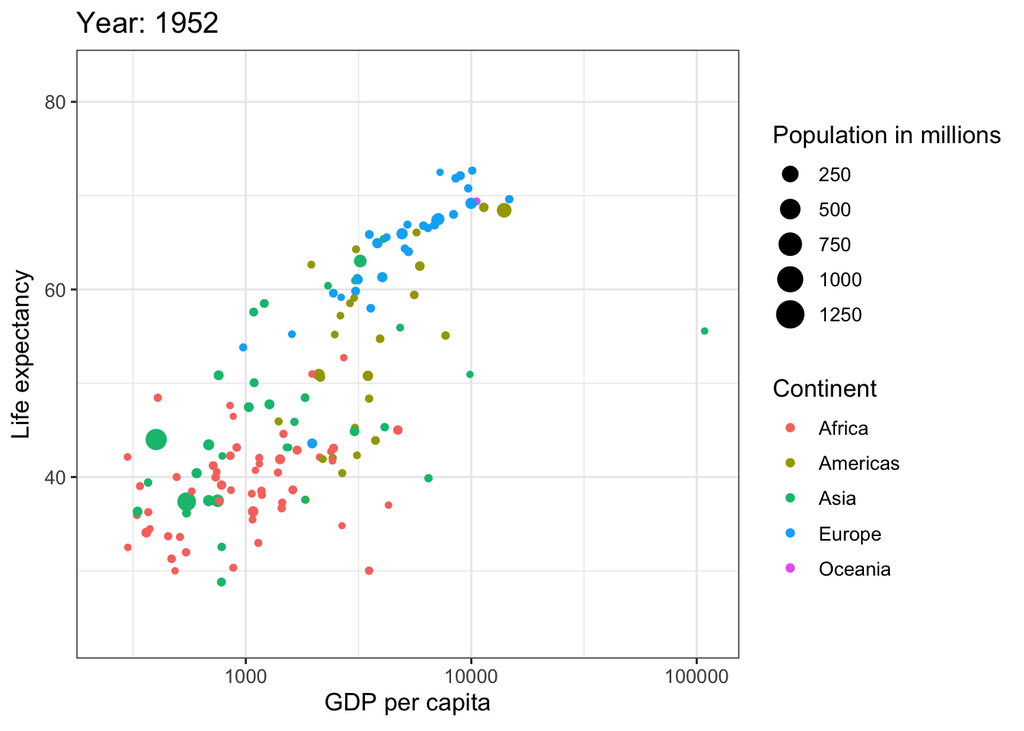

```r
anim + transition_states(year,
                      transition_length = 1,
                      state_length = 1)
```

…

Notice how the animation moves jerkily, ‘jumping’ from one year to the next 12 times in total. This is a bit clunky, which is why it’s good we have another option.

### Option 2 Animate using transition_time()

This option smooths the transition between different ‘frames’, because it interpolates and adds transitional years where there are gaps in the timeseries data.

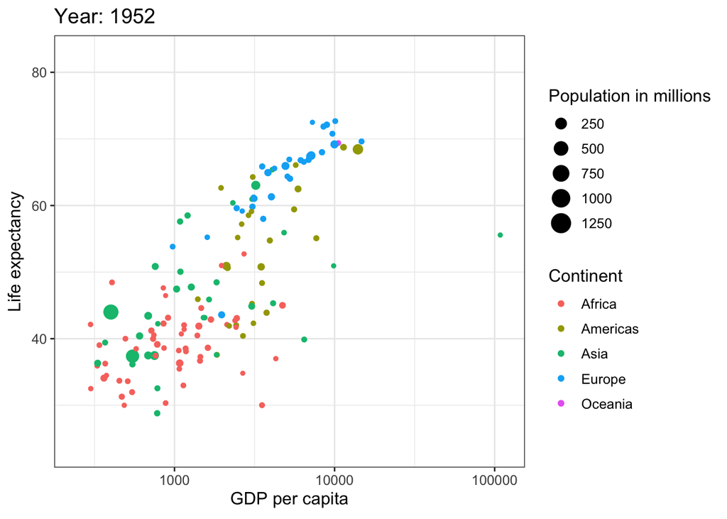

```r
anim2 <- ggplot(gapminder, aes(gdpPercap, lifeExp, size = pop/1000000)) +
  geom_point(aes(color=continent)) +
  scale_x_log10() + # convert x to log scale
  transition_time(year) +
  theme(text = element_text(size = 12)) +
  labs(size = "Population in millions",
       x = "GDP per capita",
       y = "Life expectancy",
       color = "Continent",
       title = 'Year: {frame_time}')
anim2
```

The much smoother movement in Option 2 will be much more noticeable if you add a title to the chart, that will page through the years corresponding to each frame.

Now, choose one of the animation options and get it to work. You may need to troubleshoot your installation of `gganimate` and other packages

### Tasks for the animations:

5. *Can you add a title to one or both of the animations above that will change* *in sync with the animation?* *(**Hint**: search labeling for `transition_states()` and `transition_time()` functions respectively)*

In both animations, this can be done in the labs()-function: when using transition_states() to animate, we need to put title = ‘Year: {closest_state}’, and when using transition_time(), we shall instead use write title = ‘Year: {frame_time}’ in the labs() function

6. *Can you made the axes’ labels and units more readable? Consider expanding the abbreviated labels as well as the scientific notation in the legend and x axis to whole numbers. Also, differentiate the countries from different continents by color*

### Final Question

7. **Is the world a better place today than it was in the year you were born?** *Answer this question using the gapminder data. Define better either as more prosperous, more free, more healthy, or suggest another measure that you can get from gapminder. Submit a 250 word answer with an illustration to Brightspace. Include a URL in your Brightspace submission that links to the coded solutions in Github. [Hint: if you wish to have more data than is in the filtered gapminder, you can load either the `gapminder_unfiltered` dataset or download more historical data at https://www.gapminder.org/data/ ]*

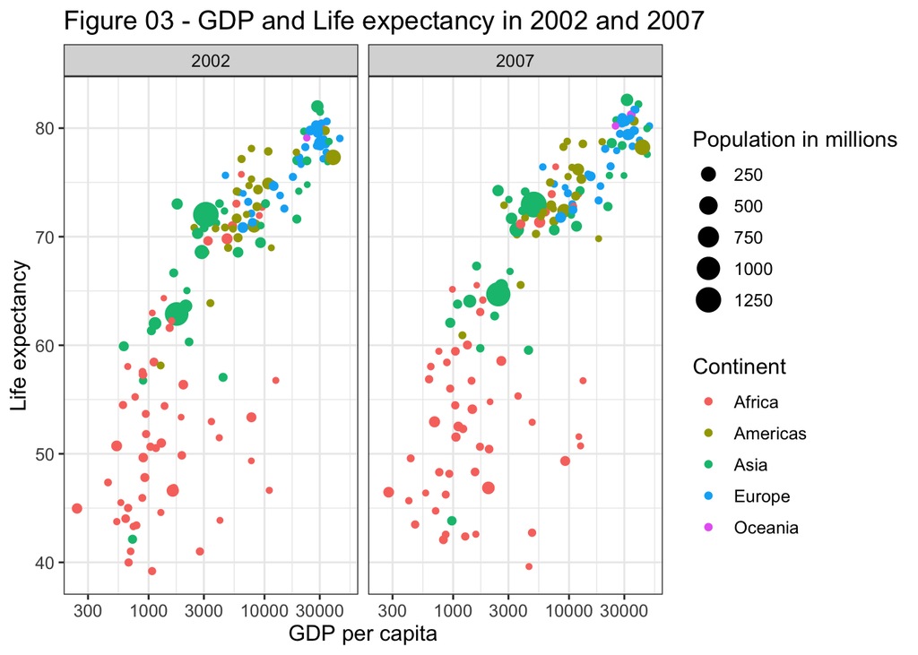

```r
gapminder %>%
  filter(year == 2002|year == 2007) %>%
  ggplot(aes(gdpPercap, lifeExp, size = pop/1000000)) +
  facet_wrap(~ year) +
  geom_point(aes(color = continent)) +
  scale_x_log10() +
  ggtitle("Figure 03 - GDP and Life expectancy in 2002 and 2007") +
  theme(text = element_text(size = 12)) +
  labs(size = "Population in millions",
       x = "GDP per capita",
       y = "Life expectancy",
       color = "Continent")
```